# Data Science Programming

## Excercises I

**1.** Lists are *recursive vectors* because they can contain other lists. This makes them fundamentally different from atomic vectors. Without typing the following code, try to guess, what the resulting structure of a list will be. Then use `str()` to check your answer.

```r
list1 <- list(1:3, "a", c(TRUE, FALSE, TRUE), c(2.3, 5.9))
list2 <- list(list(list(1)))
list3 <- list(list(1, 2), c(3, 4))
list4 <- c(list(1, 2), c(3, 4))
```

**Hint:** `c()` will combine several lists into one. If given a combination of atomic vectors and lists, `c()` will coerce the atomic vectors to lists before combining them.

**2.** Arrays, matrices, tibbles and tribbles can be created by colum- or row-binding atomic vectors. In this excercise, create two vectors: a numeric atomic vector consisting of 10 integers (`x <- 1:10`), and, a logical vector containg one TRUE and one FALSE value (`y <- c(TRUE, FALSE)`). Use these vectors to create an array (`array()`), a *matrix* (`cbind()`, `rbind()`, `matrix()`), a *data frame* (`data.frame()`), a *tibble* (tibble) and describe different behaviors of different constructors.

To explore these functions, we will use **nycflights13::flights**. This data frame contains all 336,776 flights that departed from New York City in 2013. The dataset also includes useful ‘metadata’ on airlines, airports, weather, and planes. It can be downloaded from Kaggle or R CRAN archive (https://cran.r-project.org/web/packages/nycflights13/index.html). The core data file is also available in shared folder for this course.

Should these data are loaded with `read_csv()`,a tibble is created with the following columns/attributes:

- **year, month, day:** Date of departure.
- **dep_time, arr_time:** Actual departure and arrival times (format HHMM or HMM), local tz.
- **sched_dep_time, sched_arr_time:** Scheduled departure and arrival times (format HHMM or HMM), local tz.
- **dep_delay, arr_delay:** Departure and arrival delays, in minutes. Negative times represent early departures/arrivals.
- **carrier:** Two letter carrier abbreviation.
- **flight:** Flight number.
- **tailnum:** Plane tail number.
- **origin, dest:** Origin and destination.
- **air_time:** Amount of time spent in the air, in minutes.
- **distance** Distance between airports, in miles.
- **hour, minute:** Time of scheduled departure broken into hour and minutes.
- **time_hour:** Scheduled date and hour of the flight as a POSIXct date.

Alternatively, we can use `install.packages("ncflights13")` for data loading.

```r
library(nycflights13)
nycflights13::flights[,1:7] %>% print(n = 3)
```

```
## # A tibble: 336,776 x 7
##    year month   day dep_time sched_dep_time dep_delay arr_time
##   <int> <int> <int>    <int>          <int>     <dbl>    <int>
## 1  2013     1     1      517            515         2      830
## 2  2013     1     1      533            529         4      850
## 3  2013     1     1      542            540         2      923
## # ... with 336,773 more rows
```

### Extracting variables

Unlike **nycflights13** dataset, it is not uncommon to get datasets with hundreds or even thousands of variables. If that is the case, the first challenge is often narrowing in on the variables we are actually interested in. `select()` allows us to rapidly zoom in on a useful subset using operations based on the names of the variables.

```r
nycflights13::flights %>% select(year, month, day, dep_time) %>% print(n=3)
```

```
## # A tibble: 336,776 x 4
##    year month   day dep_time
##   <int> <int> <int>    <int>
## 1  2013     1     1      517
## 2  2013     1     1      533
## 3  2013     1     1      542
## # ... with 336,773 more rows
```

There are also a number of helper functions you can use within `select()`:

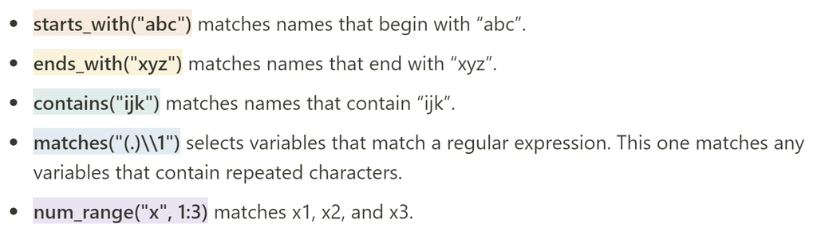

Another option is to use `select()` in conjunction with the `everything()` helper. This is useful if we have a handful of variables we would like to move to the start of the data frame:

```r
select(flights, time_hour, air_time, everything()) %>% print(n=3)
```

```
## # A tibble: 336,776 x 19
##   time_hour           air_time  year month   day dep_time sched_dep_time
##   <dttm>                 <dbl> <int> <int> <int>    <int>          <int>
## 1 2013-01-01 05:00:00      227  2013     1     1      517            515
## 2 2013-01-01 05:00:00      227  2013     1     1      533            529
## 3 2013-01-01 05:00:00      160  2013     1     1      542            540
## # ... with 336,773 more rows, and 12 more variables: dep_delay <dbl>,
## #   arr_time <int>, sched_arr_time <int>, arr_delay <dbl>, carrier <chr>,
## #   flight <int>, tailnum <chr>, origin <chr>, dest <chr>, distance <dbl>,
## #   hour <dbl>, minute <dbl>
```

Furthermore, `one_of()` argument of `select()` allows for guessing or subset-matching. Let’s say I know in general my column names will come from `c("year","month","day", "garbage")` but we do not know which columns will be present at some stage of computing because of interactivity/reactivity:

```r
nycflights13::flights %>%
  select(one_of(c("year","month","day", "garbage"))) %>%
  print(n=3)
```

```
## # A tibble: 336,776 x 3
##    year month   day
##   <int> <int> <int>
## 1  2013     1     1
## 2  2013     1     1
## 3  2013     1     1
## # ... with 336,773 more rows
```

The way to think about is that `select()` eventually evaluates to a logical vector. So if you use `starts_with()` it goes through the variables in the tibble and asks whether the variable name starts with the right set of characters. `one_of()` does the same thing, but asks whether the variable names is one of the names on the listed in the character vector.

### Adding new variables

`mutate()` always adds new columns at the end of your dataset so we’ll start by creating a narrower dataset so we can see the new variables. If we only want to keep the new variables, we use `transmute()`. Conversely, `mutate_if()` and `mutate_at()` can be used as **sed()** replacement in R.

There are many functions for creating new variables that we can use with `mutate()`. The **key property is that the function must be vectorized**: it must take a vector of values as input, and return a vector with the same number of values as output.

- Arithmetic operators +, -, *, /, ^ : These are all vectorized, using the so-called “recycling rules.” If one parameter is shorter than the other, it will be automatically extended to be the same length. This is most useful when one of the arguments is a single number: air_time / 60, hours* 60 + minute, etc.
- Modular arithmetic (%/% and %%): %/% (integer division) and %% (remainder), where x == y * (x %/% y) + (x %% y). Modular arithmetic is a handy tool because it allows you to break integers into pieces.

To demonstrate the how `mutate()` works, we will calculate average air speed for each flight in the nycflights13 dataset, using *distance* (in miles) and *air time* (in minutes) variables. The new variable *speed* is attached at the end of a tibble so we might want to move it to the start.

```r
nycflights13::flights %>%
  mutate (speed = (distance / air_time)*60) %>%
  select(speed, distance, air_time, everything()) %>%
  distinct() %>%
  print(n = 3)
```

```
## # A tibble: 336,776 x 20
##   speed distance air_time  year month   day dep_time sched_dep_time dep_delay
##   <dbl>    <dbl>    <dbl> <int> <int> <int>    <int>          <int>     <dbl>
## 1  370.     1400      227  2013     1     1      517            515         2
## 2  374.     1416      227  2013     1     1      533            529         4
## 3  408.     1089      160  2013     1     1      542            540         2
## # ... with 336,773 more rows, and 11 more variables: arr_time <int>,
## #   sched_arr_time <int>, arr_delay <dbl>, carrier <chr>, flight <int>,
## #   tailnum <chr>, origin <chr>, dest <chr>, hour <dbl>, minute <dbl>,
## #   time_hour <dttm>
```

In a similar manner, we can break down departure and arrival times to hours and minutes, as they are following HHMM formatting.

```r
nycflights13::flights %>%
  transmute(dep_time, hour = dep_time %/% 100, minute = dep_time %% 100 ) %>%
  print(n = 3)
```

```
## # A tibble: 336,776 x 3
##   dep_time  hour minute
##      <int> <dbl>  <dbl>
## 1      517     5     17
## 2      533     5     33
## 3      542     5     42
## # ... with 336,773 more rows
```

### Extracting observations

Unlike `select()`,`filter()` allows you to subset observations based on their values. The first argument is the name of the data frame. The second and subsequent arguments are the expressions that filter the data frame. For example, we can select all flights on January 1st with:

```r
nycflights13::flights %>%
  filter(month == 1, day == 1) %>%
  print(n = 3)
```

```
## # A tibble: 842 x 19
##    year month   day dep_time sched_dep_time dep_delay arr_time sched_arr_time
##   <int> <int> <int>    <int>          <int>     <dbl>    <int>          <int>
## 1  2013     1     1      517            515         2      830            819
## 2  2013     1     1      533            529         4      850            830
## 3  2013     1     1      542            540         2      923            850
## # ... with 839 more rows, and 11 more variables: arr_delay <dbl>,
## #   carrier <chr>, flight <int>, tailnum <chr>, origin <chr>, dest <chr>,
## #   air_time <dbl>, distance <dbl>, hour <dbl>, minute <dbl>, time_hour <dttm>
```

R either **prints** out the results, or **saves** them to a variable. If you want to do both, you can wrap the assignment in parentheses: `(dec25 <- filter(flights, month == 12, day == 25))`.

Multiple arguments to `filter()` are combined with “and”: every expression must be true in order for a row to be included in the output. For other types of combinations, we will need to use Boolean operators yourself: **&** is “and,” **|** is “or,” and **!** is “not.” The following code finds all flights that departed in November or December: `filter(flights, month == 11 | month == 12)`.

**Note:** We cannot write `filter(flights, month == 11 | 12)`, which might literally translates into English: “finds all flights that departed in November or December.” Instead, we write it always in full.

A useful shorthand for this problem is **x** `%in%` **y**. This will select every row where x is one of the values in y. We could use it to rewrite the preceding code:

```r
nycflights13::flights %>%
  filter(month %in% c(11, 12)) %>%
  print(n=3)
```

```
## # A tibble: 55,403 x 19
##    year month   day dep_time sched_dep_time dep_delay arr_time sched_arr_time
##   <int> <int> <int>    <int>          <int>     <dbl>    <int>          <int>
## 1  2013    11     1        5           2359         6      352            345
## 2  2013    11     1       35           2250       105      123           2356
## 3  2013    11     1      455            500        -5      641            651
## # ... with 55,400 more rows, and 11 more variables: arr_delay <dbl>,
## #   carrier <chr>, flight <int>, tailnum <chr>, origin <chr>, dest <chr>,
## #   air_time <dbl>, distance <dbl>, hour <dbl>, minute <dbl>, time_hour <dttm>
```

### Groupped summaries

```r
nycflights13::flights %>%
  group_by(year, month, day) %>%
  summarise(delay = mean(dep_delay, na.rm = TRUE))
```

```
## # A tibble: 365 x 4
## # Groups:   year, month [12]
##     year month   day delay
##    <int> <int> <int> <dbl>
##  1  2013     1     1 11.5
##  2  2013     1     2 13.9
##  3  2013     1     3 11.0
##  4  2013     1     4  8.95
##  5  2013     1     5  5.73
##  6  2013     1     6  7.15
##  7  2013     1     7  5.42
##  8  2013     1     8  2.55
##  9  2013     1     9  2.28
## 10  2013     1    10  2.84
## # ... with 355 more rows
```

```r
nycflights13::flights %>%
  select(arr_time, sched_arr_time, carrier, flight, origin, dest) %>%
  distinct() %>%
  select(carrier) %>%
  group_by(carrier) %>%
  summarise(count = n()) %>%
  arrange(desc(count))
```

```
## # A tibble: 16 x 2
##    carrier count
##    <chr>   <int>
##  1 UA      53592
##  2 EV      47114
##  3 B6      41270
##  4 DL      38498
##  5 AA      20626
##  6 MQ      17110
##  7 9E      15186
##  8 US      14138
##  9 WN       9984
## 10 VX       3400
## 11 FL       2502
## 12 AS        570
## 13 F9        518
## 14 YV        502
## 15 HA        281
## 16 OO         25
```

## Excercises II

**1.** Making use of the nycflights13::flights dataset, use tidyverse functions to find:

- which airport (labeled as *origin*) has the most delayed flights?

```r
flights <- nycflights13::flights
```

```r
flights %>% select(dep_delay, origin) %>%
  group_by(origin) %>%
  summarise(count = n()) %>%
  arrange(desc(count)) %>%
  select(origin) %>%
  print(n = 1)
```

- how many flights are shared between two carriers? (i.e. flights having the same departure tine and destination, but different tail number) ?

```r
flights %>% select(flight, carrier, dest, sched_dep_time) %>%
  distinct() %>% select(flight,carrier, dest, sched_dep_time) %>%
  group_by(dest, sched_dep_time) %>%
  summarise(count = n())
```

- what is the average delay of a flight in New York outside tourist season (i.e. from December to March) ?

```r
flights %>% select(month, flight, dest, dep_delay) %>%
  filter(month %in% c(12, 1, 2, 3)) %>%
  summarise(avg = mean(dep_delay, na.rm = TRUE))
```

- what is the average distance of delayed flights? Are short flights more delayed than the long-haul flights?

```r
flights %>%
  filter(dep_delay > 0) %>%
  summarise(avg = mean(dep_delay, na.rm = TRUE))
```

- which carrier has the most flight during summer holidays (July-August)?

```r
flights %>% select(year, month, flight, carrier) %>%
  filter(month == 7 | month == 8) %>%
  select(flight, carrier) %>%
  group_by(carrier) %>%
  summarise(count = n()) %>%
  arrange(desc(count)) %>%
  select(carrier) %>%
  print(n = 1)
```

**2.** Answer these questions without using tidyverse functions. Restrict your code to standard subsetting, as taught through the course. Note that there is a replacement for the function n(), which is used with functional summarise(), which is called table().